# Come si ricava il comune di una lettura

La scelta di `correggi_comune_lettura()`, con esempi calcolati dal codice

Data di Pubblicazione

30/10/2026

Il campo `comune_lettura` dice in quale comune è stata fatta una lettura. Da lì vengono il cantiere, i filtri per comune sulla mappa, le bolle e la coerenza del comune (`Coerente`, `Fuori comune`, `Fuori giro`). Il sistema di localizzazione dei mezzi lo scrive già, ma vicino ai confini, o per una frazione, a volte sbaglia: per questo la pipeline lo controlla con la posizione.

# Da quali dati si ricava

[interactive chart not shown]

- **Indirizzo del sistema di localizzazione** (`IndirizzoLocalizzazione`): un testo «via, comune». Il comune è la parte dopo la prima virgola.
- **Posizione**: latitudine e longitudine della lettura.
- **Confini dei comuni serviti**: i 66 comuni dell’azienda, con i confini della Regione del Veneto (non semplificati).
- **Comune della fornitura** (`comune_fornitura`): il comune del contenitore secondo il database, nel giorno della lettura. Non esiste per i non censiti e per i sacchetti.

# Prima di tutto: quali letture entrano

- Le letture con latitudine zero o senza comune dopo la virgola **si tengono** (dal 30/10/2026): sono comunque bidoni letti. Restano con la posizione e il comune vuoti, e il comune si ricava dalla posizione solo dove c’è.
- Per ogni RFID resta *una lettura al giorno*: la prima in ordine di tempo tra quelle che hanno una posizione e, se nessuna ce l’ha, la prima in ordine di tempo. Il controllo si fa dopo la pulizia dei codici (`formatta_rfid()`), perché due codici letti male possono diventare lo stesso RFID.
- Solo i mezzi con il test delle antenne positivo, e solo dal giorno dopo il test.

# Il percorso

La scelta avviene dopo l’associazione al database, perché serve il comune della fornitura.

[interactive chart not shown]

Il GPS e la fornitura si confrontano senza badare a maiuscole, accenti e apostrofi (`chiave_comune()`), e un nome del GPS portato alla grafia della tabella non conta come correzione («Rosa’» e `ROSÀ` sono lo stesso comune).

# I sei casi

| Caso | Comune del GPS | Comune della fornitura | Posizione | comune_lettura | In comuni_corretti.csv |
| --- | --- | --- | --- | --- | --- |
| A | LIMENA | LIMENA | NOVE | LIMENA | no |
| B | LIMENA | CITTADELLA | NOVE | NOVE | sì |
| C | LIMENA | CITTADELLA | fuori dai comuni serviti | LIMENA | no |
| D | MESTRE | CITTADELLA | NOVE | NOVE | sì |
| E | MESTRE | nessuno | fuori dai comuni serviti | MESTRE | no |
| F | LIMENA | CITTADELLA | senza coordinate | LIMENA | no |

Il caso A è quello segnalato dal proprietario: vicino al confine la posizione può dare il comune accanto, mentre il GPS e il database sono d’accordo. Un cambio di sola grafia non conta come correzione, e non entra in `comuni_corretti.csv`.

# Come si capisce che un punto è dentro un comune

Per ogni comune servito si guarda prima il rettangolo che racchiude il suo confine (un filtro veloce), poi, solo per i punti che ci cadono, si conta quanti lati del confine attraversa una semiretta che parte dal punto: **un numero dispari di lati vuol dire dentro**. Il primo comune che contiene il punto vince. I punti con le stesse coordinate si calcolano una volta sola.

Il disegno usa un confine inventato, con una rientranza, e `dentro_poligoni()` del pacchetto per dare l’esito di ogni punto.

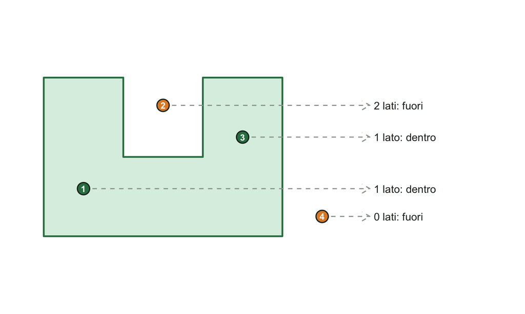

Il punto 2 sta nella rientranza: la semiretta attraversa due lati e il punto è fuori. Il punto 4 è fuori e attraversa zero lati.

# Che cosa ne deriva

- **Cantiere**: quello del comune finale, secondo la tabella dei comuni. Per un comune fuori tabella resta vuoto.
- **Distanza dal comune dichiarato**: per una lettura fatta in un comune diverso da quello dichiarato (database per un censito, giro per un non censito) si calcolano i metri dal suo confine.
- **Coerenza del comune**: `Coerente` se il comune finale è quello dichiarato o la distanza è entro 100 metri; altrimenti `Fuori comune` (censito) o `Fuori giro` (non censito); `Coerenza ignota` se manca uno dei due comuni, o se il comune del giro è una zona fuori tabella.
- **Nell’app**: il comune di lettura si usa così com’è. Un comune fuori tabella dà un avviso al caricamento, nessun cantiere e la voce «Non assegnato» nei filtri.

# `comuni_corretti.csv`

La pipeline scrive in `data-raw/output/` l’elenco delle letture il cui comune finale è diverso da quello del sistema di localizzazione: data e ora, mezzo, RFID, coordinate, `comune_gps`, `comune_fornitura`, `comune_posizione`. Serve a controllare le correzioni: per i bidoni censiti si vede quante volte la posizione coincide con la fornitura.

# Scelte e limiti da conoscere

- **La posizione è più precisa del GPS** (verificato dal proprietario sulle letture dei censiti: `comune_posizione` coincide con `comune_fornitura` molto più spesso di `comune_gps`). L’eccezione è il caso A, scelto il 23 ottobre 2026.
- **Il caso A ha un effetto sulla coerenza.** Per un censito, se il GPS coincide con la fornitura la lettura risulta coerente anche quando il punto è già nel comune accanto. Un bidone davvero spostato in un comune confinante, letto con un GPS che scrive ancora il comune vecchio, non verrebbe segnalato «fuori comune».
- **Per i non censiti conta solo la posizione**: la regola del caso A non si applica, perché non c’è un comune della fornitura.
- **Confini della Regione contro confini del sistema di localizzazione.** Non sono gli stessi: vicino al confine i due possono dare comuni diversi. La tolleranza di 100 metri sulla coerenza copre in parte questa differenza.
- **Letture fuori dai comuni serviti** (casi C ed E) tengono il nome del sistema di localizzazione: non è verificabile con i confini che abbiamo.
- **Comuni soppressi o scritti diversamente.** `VALSTAGNA` è stato riportato a `VALBRENTA` nell’anagrafica dei contenitori; un nome del GPS non in tabella si risolve con la posizione.

# Come si cambia

La scelta sta in `correggi_comune_lettura()`; l’importazione in `importa_letture_antenne()`; il calcolo del punto in `comune_del_punto()` (`R/utils_geografia.R`); l’ordine dei passi in `prepara_letture_antenne()`. I test sono in `test-fct_preparazione_letture.R` e `test-fct_importa_tabelle.R`. Quando la logica cambia vanno aggiornati questo file (la tabella dei casi si ricalcola da sola, il testo no), `CLAUDE.md` e il README, e il documento va ricompilato.